How to calculate summary statistics of variables, which also includes a quick explanation of how to write your own functions in R Studio.

# 1 Housekeeping

Remember that `rm(list=ls())` is not sufficient for a full clean set up of R, and you should use `Ctrl/Cmd-SHIFT-F10` in Rstudio to Restart R cleanly and check that this works at least at the end of your analysis, or periodically during development.

```r
# remove (almost) all objects currently held in the R environment
rm(list=ls())
```

# 2 Summary statistics

Generate some summary statistics on the Petal Lengths manually

```r
mu <- mean(iris$Petal.Length)    # mean
med <- median(iris$Petal.Length)  # median
variance <- var(iris$Petal.Length)     # variance
stan.dev <- sd(iris$Petal.Length)      # standard deviation
n <- length(iris$Petal.Length) # the number of observations
standard.error <- sd(iris$Petal.Length) / sqrt(length(iris$Petal.Length)) # SE of the mean
maximum <- max(iris$Petal.Length, na.rm=T)
minimum <- min(iris$Petal.Length, na.rm=T)
```

NAs can cause problems for functions, and many take an optional argument `na.rm` which takes either `TRUE` or `FALSE` and removes the NAs prior to calculating the summary statistic. You need to take care of this as if NAs appear in vectors, they can propagate very easily and break code as you can end up with entire vectors and matrices of NAs where you intend there to be numbers. That said, NAs are often informative (e.g. identifying missing, often partially missing, information), and there are good reasons for keeping them in the vectors and matrices but ignoring them as required.

```r
# min of a vector with NA
min(c(1,5,2,NA,3))
```

```
## [1] NA
```

```r
# ingore the NAs
min(c(1,5,2,NA,3), na.rm=T)
```

```
## [1] 1
```

But… we probably want to calculate these metrics for each of the three species seperately. Use the function aggregate() to collect the data into subsets associated with each species, and apply a given function to the subset. It probably helps if we have a quick graph of the data as a reference point for these summary statistics. A boxplot does this and i refer you to the associated podcast on boxplots for more information

To remmeber how did the data look like:

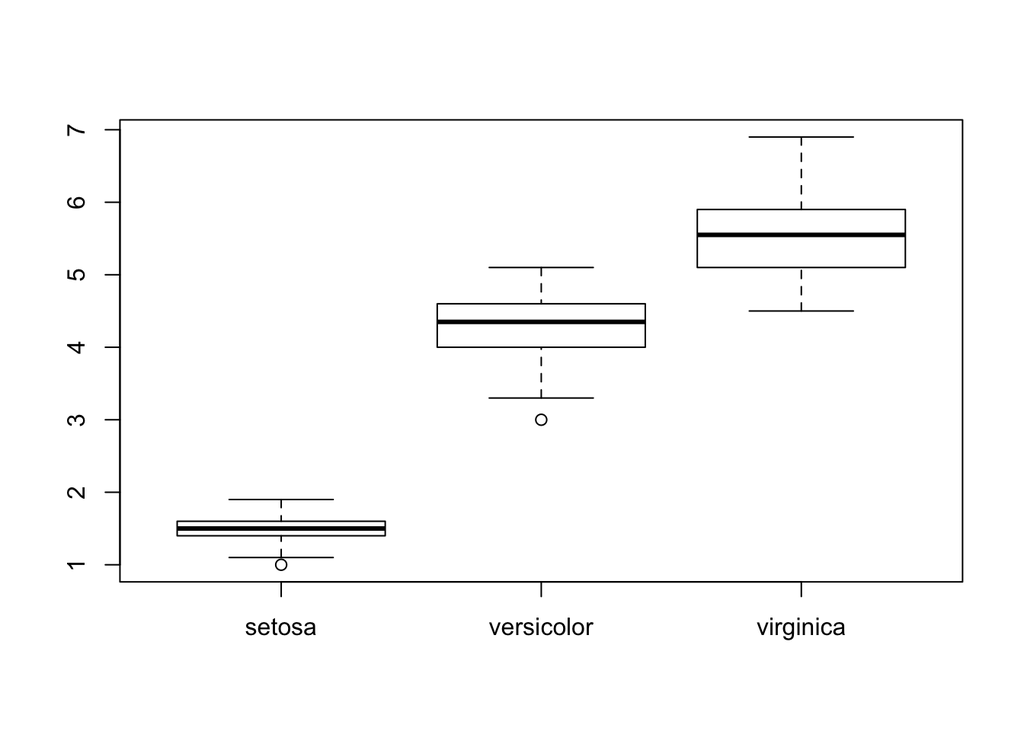

```r
boxplot(iris$Petal.Length ~ iris$Species)
```

```r
mu.sepal.lengths <- aggregate(iris$Petal.Length, by=list(iris$Species), mean)
mu.sepal.lengths
```

```
##      Group.1     x
## 1     setosa 1.462
## 2 versicolor 4.260
## 3  virginica 5.552
```

```r
# or
# (mu.sepal.lengths <- aggregate(iris$Petal.Length, by=list(iris$Species), mean))
```

If you want just simple statistics with build in functions you can use summary function which calculates:

```r
summary(iris$Petal.Length) # for all Petal lengths
```

```
##    Min. 1st Qu.  Median    Mean 3rd Qu.    Max.
##   1.000   1.600   4.350   3.758   5.100   6.900
```

```r
tapply(iris$Petal.Length, iris$Species, summary) # for Petal length by species
```

```
## $setosa
##    Min. 1st Qu.  Median    Mean 3rd Qu.    Max.
##   1.000   1.400   1.500   1.462   1.575   1.900
##
## $versicolor
##    Min. 1st Qu.  Median    Mean 3rd Qu.    Max.
##    3.00    4.00    4.35    4.26    4.60    5.10
##
## $virginica
##    Min. 1st Qu.  Median    Mean 3rd Qu.    Max.
##   4.500   5.100   5.550   5.552   5.875   6.900
```

```r
IQR(iris$Petal.Length)
```

```
## [1] 3.5
```

```r
z<-c(1,2,4,5)
z
```

```
## [1] 1 2 4 5
```

We could repeat this for all the metrics, but instead, we can write our own function that calculates a series of useful summary statistics on the data.

Let’s specify our own function

```r
summaryStats <- function (x,...) {

# "out" will be a vector with names assigned to each entry.
out <- c( n.obs = length(x),
          min   = min(x),
          qtile = quantile(x,c(0.25,0.5,0.75)),
          max   = max(x),
          mean  = mean(x),
          sd    = sd(x),
          var   = var(x),
          se    = sd(x)/sqrt(length(x))
          )

return(out)  # this tells the function what to return as "the answer"
} # end of function
```

Let’s apply our new function on our vector z.

```r
summaryStats(z)
```

```
##     n.obs       min qtile.25% qtile.50% qtile.75%       max      mean
## 4.0000000 1.0000000 1.7500000 3.0000000 4.2500000 5.0000000 3.0000000
##        sd       var        se
## 1.8257419 3.3333333 0.9128709
```

Now apply our summaryStats() function to the Petal Length data by Species

```r
petal.length.summaries <- aggregate(iris$Petal.Length,
                                    by = list(iris$Species),
                                    summaryStats)
petal.length.summaries
```

```
##      Group.1     x.n.obs       x.min x.qtile.25% x.qtile.50% x.qtile.75%
## 1     setosa 50.00000000  1.00000000  1.40000000  1.50000000  1.57500000
## 2 versicolor 50.00000000  3.00000000  4.00000000  4.35000000  4.60000000
## 3  virginica 50.00000000  4.50000000  5.10000000  5.55000000  5.87500000
##         x.max      x.mean        x.sd       x.var        x.se
## 1  1.90000000  1.46200000  0.17366400  0.03015918  0.02455980
## 2  5.10000000  4.26000000  0.46991098  0.22081633  0.06645545
## 3  6.90000000  5.55200000  0.55189470  0.30458776  0.07804970
```

However, take care that you need first to run function and then you can use it for the variables of interest within dataset.

ASSIGNMENT:

1. Add interquantile range IQR into your function called summary.stats1 and perform calculation for Sepal.Length and store values into sepal.length.summaries.

Solution:

```r
summaryStats1 <- function (x,...) {

# "out" will be a vector with names assigned to each entry.
out <- c( n.obs = length(x),
          min   = min(x),
          qtile = quantile(x,c(0.25,0.5,0.75)),
          max   = max(x),
          mean  = mean(x),
          sd    = sd(x),
          var   = var(x),
          se    = sd(x)/sqrt(length(x)),
          IQR = IQR(x)
          )

return(out)  # this tells the function what to return as "the answer"
}
sepal.length.summaries <- aggregate(iris$Sepal.Length,by=list(iris$Species),summaryStats1)
sepal.length.summaries
```

```
##      Group.1     x.n.obs       x.min x.qtile.25% x.qtile.50% x.qtile.75%
## 1     setosa 50.00000000  4.30000000  4.80000000  5.00000000  5.20000000
## 2 versicolor 50.00000000  4.90000000  5.60000000  5.90000000  6.30000000
## 3  virginica 50.00000000  4.90000000  6.22500000  6.50000000  6.90000000
##         x.max      x.mean        x.sd       x.var        x.se       x.IQR
## 1  5.80000000  5.00600000  0.35248969  0.12424898  0.04984957  0.40000000
## 2  7.00000000  5.93600000  0.51617115  0.26643265  0.07299762  0.70000000
## 3  7.90000000  6.58800000  0.63587959  0.40434286  0.08992695  0.67500000
```